# Lab 3: Gesture Recognition using Convolutional Neural Networks

### Part (c) - 5 pt

Train your new network, including any hyperparameter tuning. Plot and submit the training curve of your best model only.

Note: Depending on how you are caching (saving) your AlexNet features, PyTorch might still be tracking updates to the **AlexNet weights**, which we are not tuning. One workaround is to convert your AlexNet feature tensor into a numpy array, and then back into a PyTorch tensor.

```python
model = AlexNet("Transfer")
if torch.cuda.is_available():
    model = model.cuda()
train(model, overfitting=True, batch_size=30, learning_rate=0.0001, num_epochs=30, replace=[training_store, validation_store])
```

```
WARNING: only overfit testing should be here
WARNING: only transfer learning should be here
Epoch 1: Train err: 0.3036619718309859, Train loss: 1.0847654354876615 | Validation err: 0.2613065326633166, Validation loss: 0.7657881107312351
Epoch 2: Train err: 0.09521126760563381, Train loss: 0.42853839818142275 | Validation err: 0.1507537688442211, Validation loss: 0.5529330226232358
Epoch 3: Train err: 0.056901408450704224, Train loss: 0.2489131877365732 | Validation err: 0.09045226130653267, Validation loss: 0.45229160907179883
Epoch 4: Train err: 0.029295774647887324, Train loss: 0.15597657999262313 | Validation err: 0.08542713567839195, Validation loss: 0.39956174211241446
Epoch 5: Train err: 0.013521126760563381, Train loss: 0.10176572216012779 | Validation err: 0.08542713567839195, Validation loss: 0.36615841644703123
Epoch 6: Train err: 0.009014084507042254, Train loss: 0.06742422185551017 | Validation err: 0.08542713567839195, Validation loss: 0.33652714205205125
Epoch 7: Train err: 0.0033802816901408453, Train loss: 0.04473412071367596 | Validation err: 0.08040201005025126, Validation loss: 0.31684677446842663
Epoch 8: Train err: 0.0016901408450704226, Train loss: 0.02920821819117132 | Validation err: 0.07537688442211055, Validation loss: 0.3036408945719775
Epoch 9: Train err: 0.0011267605633802818, Train loss: 0.01914534719272106 | Validation err: 0.07537688442211055, Validation loss: 0.3018788439733779
Epoch 10: Train err: 0.0005633802816901409, Train loss: 0.012600966079339125 | Validation err: 0.07537688442211055, Validation loss: 0.3052571710255885
Epoch 11: Train err: 0.0005633802816901409, Train loss: 0.009003958460711952 | Validation err: 0.07537688442211055, Validation loss: 0.31066260782775995
Epoch 12: Train err: 0.0011267605633802818, Train loss: 0.007256976771134037 | Validation err: 0.06532663316582915, Validation loss: 0.32115360193244546
Epoch 13: Train err: 0.0011267605633802818, Train loss: 0.006124770340234892 | Validation err: 0.06532663316582915, Validation loss: 0.3342275365027025
Epoch 14: Train err: 0.0011267605633802818, Train loss: 0.005240989505440927 | Validation err: 0.06532663316582915, Validation loss: 0.3513627858500299
Epoch 15: Train err: 0.0011267605633802818, Train loss: 0.005598771914923018 | Validation err: 0.06532663316582915, Validation loss: 0.36940493418324905
Epoch 16: Train err: 0.0011267605633802818, Train loss: 0.005582923383034132 | Validation err: 0.06532663316582915, Validation loss: 0.39580210003739835
Epoch 17: Train err: 0.0011267605633802818, Train loss: 0.004456707582628901 | Validation err: 0.06532663316582915, Validation loss: 0.403875485935086
Epoch 18: Train err: 0.0011267605633802818, Train loss: 0.006822154298080502 | Validation err: 0.06532663316582915, Validation loss: 0.4341712613727664
Epoch 19: Train err: 0.0011267605633802818, Train loss: 0.006179120398283187 | Validation err: 0.06532663316582915, Validation loss: 0.45454105023543706
Epoch 20: Train err: 0.0011267605633802818, Train loss: 0.006264986240026428 | Validation err: 0.07035175879396985, Validation loss: 0.47560062157676053
Epoch 21: Train err: 0.0011267605633802818, Train loss: 0.006532649485183593 | Validation err: 0.07035175879396985, Validation loss: 0.5013516043531382
Epoch 22: Train err: 0.0005633802816901409, Train loss: 0.005773988908090884 | Validation err: 0.07035175879396985, Validation loss: 0.508955570331471
Epoch 23: Train err: 0.0011267605633802818, Train loss: 0.005479529750946176 | Validation err: 0.06532663316582915, Validation loss: 0.5258917389151211
Epoch 24: Train err: 0.0011267605633802818, Train loss: 0.004958175305614107 | Validation err: 0.06532663316582915, Validation loss: 0.544205167477745
Epoch 25: Train err: 0.0011267605633802818, Train loss: 0.004968356897384879 | Validation err: 0.06532663316582915, Validation loss: 0.5736909306675745
Epoch 26: Train err: 0.0011267605633802818, Train loss: 0.007387196722680551 | Validation err: 0.07537688442211055, Validation loss: 0.633221154507613
Epoch 27: Train err: 0.0011267605633802818, Train loss: 0.00708199438816879 | Validation err: 0.07537688442211055, Validation loss: 0.6539957123562324
Epoch 28: Train err: 0.0011267605633802818, Train loss: 0.007091564141300404 | Validation err: 0.08040201005025126, Validation loss: 0.6987219198467014
Epoch 29: Train err: 0.0005633802816901409, Train loss: 0.006157495049453532 | Validation err: 0.07035175879396985, Validation loss: 0.653696787518075
Epoch 30: Train err: 0.0011267605633802818, Train loss: 0.005313563793034858 | Validation err: 0.07035175879396985, Validation loss: 0.675511242401347
Finished Training
```

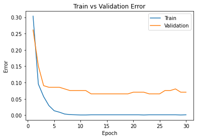

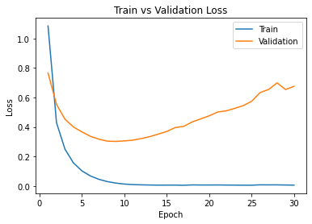

```python
model_path = get_model_name("Transfer", batch_size=30, learning_rate=0.0001, epoch=29)
plot_training_curve(model_path)
```

### Part (d) - 2 pt

Report the test accuracy of your best model. How does the test accuracy compare to Part 3(d) without transfer learning?

```python
criterion = nn.CrossEntropyLoss()
test_err, test_loss = evaluate(model, testing_store, criterion)

print("Test error:", test_err)
print("Test loss:", test_loss)
```

```
Test error: 0.04522613065326633
Test loss: 0.20237362812151202
```

##### As we can see, this model **(4.5% error, 20.2% loss)** performs better compared to Part3(d) **(10% error, 42.8% loss)**

### 5. Additional Testing [5 pt]

For this question you should just reuse the small dataset that you used to answer question 2c.

Using the best transfer learning model developed in Part 4. Report the test accuracy on your sample images and how it compares to the test accuracy obtained in Part 4(d)? How well did your model do for the different hand guestures? Provide an explanation for why you think your model performed the way it did?

```python
criterion = nn.CrossEntropyLoss()
test_err, test_loss = evaluate(model, overfit_store, criterion)

print("Test error:", test_err)
print("Test loss:", test_loss)
```

```
Test error: 0.06521739130434782
Test loss: 0.17022235944834394
```

The test accuracy is approximately the same as Part 4(d), only a little bit lower.

- Good accuracy since the AlexNet CNN has deeper layers and pre-trained weights that can extract image features very well.
- Quite similar to testing accuracy since the datasets are guaranteed to be separate (split from get_data_loader) so for the model, the test set and overfit set are similar (things that is has never seen before)
- Accuracy is a bit less than testing, also possibly because the number of data tested in this set is much smaller, so errors are more expensive